# RCEF stock coordination

Edvin Fuglebakk

2024-03-20

Some proof-of-concept checks to verify that candidates for an exchange format for National / Regional estimation in RDBES/TAF can be used for stock-coordination purposes.

## Format

We will define some preliminary vocabularies for the columns that are valid in the RCEF format:

```r
POPULATION_VARIABLES <- c("vesselFlagCountry", "year", "catchCategory", "speciesCode")
ACTIVITY_DOMAIN_VARIABLES <- c("quarter",   "month","stockArea",    "area", "metier6",  "fleet")
FISH_DOMAIN_VARIABLES <- c("sex", "maturity", "domainVariable", "minValue", "maxValue")
ESTIMATES_VALUE_VARIABLES <- c("total", "mean", "varianceTotal", "varianceMean")
SAMPLE_DESCRIPTION_VARIABLES <- c("numSamples", "numMeas","sampledCatchKg","sampledCatchT","sampledCatchPC")
```

Some example files are located in ../data .

## Sum of product test

An example of how to perform a sum of product test is provided in the following functions:

```r
#' Perform a sum of product tests.
#' Calculates the sum of the product of abundance and mean weight in a domain and compares it to total catch.
#' @param RCEF domain definitions and estimates in the RCEF format.
#' @return table with total weights in domain, SOP-estimates, and the relative differences
sopTest <- function(RCEF){
  abundance <- RCEF$ESTIMATES[variable=="Abundance",]
  abundance$totalN <- abundance$total
  meanW <- RCEF$ESTIMATES[variable=="WeightLive",]
  meanW$meanWeight <- meanW$mean
  tabSOP <- merge(abundance, meanW, by=c(POPULATION_VARIABLES, "fishDomain", "activityDomain"))

  sop <- tabSOP[,list(sopWeight=sum(totalN*meanWeight)/1000),by="activityDomain"]
  totalCatch <- RCEF$CATCH[,list(totalWeight=sum(scientificWeight)),by="activityDomain"]

  resultTab <- merge(totalCatch, sop, all.x=T)
  resultTab$relDiff <- (resultTab$sopWeight - resultTab$totalWeight) / resultTab$totalWeight

  return(resultTab)
}
```

## Aggregate domains

An example of how estimates for activity domains can be aggregated is provided in the following function:

```r
#' @param RCEF domain definitionns and estimates in the RCEF format.
#' @param desiredDomains table defining desiredDomains. Contain valid domain variables and a column 'activityDomain'
aggregateActivityDomains <- function(RCEF, desiredDomains){

  catch <- data.table::as.data.table(RCEF$CATCH)
  estimates <- data.table::as.data.table(RCEF$ESTIMATES)
  desiredDomains <- data.table::as.data.table(desiredDomains)

  #check that the desired domain is defined in terms of valid activity domain variables
  stopifnot(all(names(desiredDomains) %in% c(ACTIVITY_DOMAIN_VARIABLES, "activityDomain")))

  #check that all activity domains in estimates are defined in the catch table
  stopifnot(all(catch$activityDomain %in% catch$activityDomain))

  #handle domain variables not in domain definition for estimates
  domainCount <- desiredDomains[,list(NDomains=length(unique(activityDomain))), by=names(desiredDomains)[!(names(desiredDomains) %in% names(catch))]]
  if (ncol(domainCount)>1 & any(domainCount$NDomains>1)){
    stop("Desired domains specify finer resolution that domains estimates are provided for")
  }

  # domains encompass all values for domain variables not provided
  desiredDomains <- desiredDomains[,.SD, .SDcol=names(desiredDomains)[names(desiredDomains) %in% names(catch)]]
  if (ncol(desiredDomains) == 1){
    stoptifnot(length(unique(desiredDomain$activtyDomain))!=1)
    catch$actvityDomain <- desiredDomain$activtyDomain
  }
  else{
    catch <- merge(catch, desiredDomains, by=names(desiredDomains)[names(desiredDomains)!="activityDomain"], suffixes=c("", ".desired"))

    domainCount <- catch[,list(NDomains=unique(activityDomain.desired)), by="activityDomain"]
    if (any(domainCount$Ndomains>1)){
      stop("Some estimated domains are in more than one desired domain.")
    }
  }

    #insert NAs for any unsampled domains
  DOMS <- catch[!duplicated(apply(catch[,.SD,.SDcol=c(POPULATION_VARIABLES, "activityDomain")],
                                                        MARGIN=1, FUN=paste, collapse=",")),.SD,
                                      .SDcol=c(POPULATION_VARIABLES, "activityDomain")]
  DOMS$k<-1
  DOMS <- merge(data.table::CJ(k=1, variable=unique(estimates$variable), fishDomain=unique(estimates$fishDomain)), DOMS, by="k", allow.cartesian = T)
  estimates <- merge(estimates, DOMS, by=c("variable", POPULATION_VARIABLES, "activityDomain", "fishDomain"), all.y=T)


  estimates$activityDomain.desired <- catch$activityDomain.desired[match(estimates$activityDomain, catch$activityDomain)]

  catch$activityDomain <- catch$activityDomain.desired
  catch$activityDomain.desired <- NULL

  estimates$activityDomain <- estimates$activityDomain.desired
  estimates$activityDomain.desired <- NULL


  #infer optionally present columns
  for (val in ESTIMATES_VALUE_VARIABLES){
    if (is.null(estimates[[val]])){
      estimates[[val]] <- as.numeric(NA)
    }
  }

  # aggregate totals
  aggTotals <- estimates[,list(total=sum(total), varianceTotal=sum(varianceTotal)), by=c("variable", "fishDomain", "activityDomain", POPULATION_VARIABLES)]

  totalN <- aggTotals[variable=="Abundance",]
  totalN$totalNumber <- totalN$total
  estimates <- merge(estimates, totalN[,.SD,.SDcol=c("totalNumber", "fishDomain", "activityDomain", POPULATION_VARIABLES)], by=c("fishDomain", "activityDomain", POPULATION_VARIABLES), all.x=T)

  # aggregate means
  aggMeans <- estimates[,list(mean = sum(mean*totalNumber)/sum(totalNumber), varianceMean = sum(varianceMean * (totalNumber/sum(totalNumber))**2)), by=c("variable", "fishDomain", "activityDomain", POPULATION_VARIABLES)]

  aggregated <- merge(aggTotals, aggMeans, by=c("variable", "fishDomain", "activityDomain", POPULATION_VARIABLES))

  # iterate over sample variables and set to NA
  for (e in names(estimates)){
    if (e %in% SAMPLE_DESCRIPTION_VARIABLES){
      aggregated[[e]] <- as.numeric(NA)
    }
  }

  RCEF$ESTIMATES <- aggregated
  RCEF$CATCH <- catch

  return(RCEF)
}
```

Note that aggregation of means requires different treatment than the simply additive statistics. May consider a more general encoding, where we parameterise variable, and provide Total, Mean, VarTotal, and VarMean for that variable. That was also one of the proposed solutions to handle different length variables (total length, carapax length, fork length, etc).

It is not clear that sample description parameters can be aggregated across activity domains. If PSU is for instance a landing event, some activity domain variables like gear can be covered by the same samples and it is unclear if it can be added. Perhaps these should just be NA as here, be defined as lower bound on sampling, or we need a slightly different format for aggregated results omitting them altogether.

Applying this function to an example file with the estimates reported by age and gear:

```r
domainEstimates <- readRDS("../data/estimates_gear_caa.rds")
desiredDomains <- data.table::data.table(activityDomain="NSHER", metier6=c("OTB_SPF_>0_0_0_all","OTM_SPF_>0_0_0_all","PS1_SPF_>0_0_0_all"))
totalAggregatedEstimates <- aggregateActivityDomains(domainEstimates, desiredDomains)
totalAggregatedEstimates$ESTIMATES
```

```
## Key: <variable, fishDomain, activityDomain, vesselFlagCountry, year, catchCategory, speciesCode>
##       variable fishDomain activityDomain vesselFlagCountry  year catchCategory speciesCode       total varianceTotal     mean
##         <char>     <char>         <char>            <char> <int>        <char>       <num>       <num>         <num>    <num>
##  1:  Abundance      Age 1          NSHER                NO  2022           Lan      126417    20320134  1.894270e+14       NA
##  2:  Abundance    Age 10+          NSHER                NO  2022           Lan      126417    12727096  8.234444e+12       NA
##  3:  Abundance      Age 2          NSHER                NO  2022           Lan      126417   524320381  4.659350e+15       NA
##  4:  Abundance      Age 3          NSHER                NO  2022           Lan      126417    96257127  3.199446e+14       NA
##  5:  Abundance      Age 4          NSHER                NO  2022           Lan      126417    35795382  6.175973e+13       NA
##  6:  Abundance      Age 5          NSHER                NO  2022           Lan      126417    24878722  3.561279e+13       NA
##  7:  Abundance      Age 6          NSHER                NO  2022           Lan      126417    83139223  4.243558e+14       NA
##  8:  Abundance      Age 7          NSHER                NO  2022           Lan      126417    12071000  8.098278e+12       NA
##  9:  Abundance      Age 8          NSHER                NO  2022           Lan      126417    40723167  1.018073e+14       NA
## 10:  Abundance      Age 9          NSHER                NO  2022           Lan      126417    17214698  1.668556e+13       NA
## 11: WeightLive      Age 1          NSHER                NO  2022           Lan      126417  1173089034  5.747000e+17      NaN
## 12: WeightLive    Age 10+          NSHER                NO  2022           Lan      126417  2959390141  4.388843e+17 220.6690
```

[output cut: 32 more lines]

```r
sum(totalAggregatedEstimates$ESTIMATES$total[totalAggregatedEstimates$ESTIMATES$variable=="Abundance"]) - sum(domainEstimates$ESTIMATES$total[domainEstimates$ESTIMATES$variable=="Abundance"])
```

```
## [1] -1.192093e-07
```

Similarly, grouping only two gears:

```r
desiredDomains <- data.table::data.table(activityDomain=c("OT", "OT", "PS"), metier6=c("OTB_SPF_>0_0_0_all","OTM_SPF_>0_0_0_all","PS1_SPF_>0_0_0_all"))
aggregatedEstimates <- aggregateActivityDomains(domainEstimates, desiredDomains)
aggregatedEstimates$ESTIMATES
```

```
## Key: <variable, fishDomain, activityDomain, vesselFlagCountry, year, catchCategory, speciesCode>
##       variable fishDomain activityDomain vesselFlagCountry  year catchCategory speciesCode       total varianceTotal     mean
##         <char>     <char>         <char>            <char> <int>        <char>       <num>       <num>         <num>    <num>
##  1:  Abundance      Age 1             OT                NO  2022           Lan      126417    20320134  1.894270e+14       NA
##  2:  Abundance      Age 1             PS                NO  2022           Lan      126417           0  0.000000e+00       NA
##  3:  Abundance    Age 10+             OT                NO  2022           Lan      126417    10158288  6.246362e+12       NA
##  4:  Abundance    Age 10+             PS                NO  2022           Lan      126417     2568808  1.988082e+12       NA
##  5:  Abundance      Age 2             OT                NO  2022           Lan      126417   270865568  3.476731e+15       NA
##  6:  Abundance      Age 2             PS                NO  2022           Lan      126417   253454813  1.182619e+15       NA
##  7:  Abundance      Age 3             OT                NO  2022           Lan      126417    43280096  6.398537e+13       NA
##  8:  Abundance      Age 3             PS                NO  2022           Lan      126417    52977032  2.559592e+14       NA
##  9:  Abundance      Age 4             OT                NO  2022           Lan      126417    25242750  4.785620e+13       NA
## 10:  Abundance      Age 4             PS                NO  2022           Lan      126417    10552632  1.390353e+13       NA
## 11:  Abundance      Age 5             OT                NO  2022           Lan      126417    20388590  3.268938e+13       NA
## 12:  Abundance      Age 5             PS                NO  2022           Lan      126417     4490132  2.923407e+12       NA
```

[output cut: 72 more lines]

## Imputing mean weight

If estimates cannot be provided for a certain activity domain, or they are provided with too low precision, one may desire to impute mean weight and weigth fraction in fishdomains (e.g. age groups) from a different activity domain, and provide totalNumber as a ratio estimate. An example is provided in the following function:

```r
#' @param RCEF
#' @param imputeTo The activity domain to impute to
#' @param imputeFrom The activity domain to impute from
#' @param totalWeightField Indicate which field to use for totalWeight. 'official' or 'scientific'
imputeMeanWeight <- function(RCEF, imputeTo, imputeFrom, totalWeightField){

  stopifnot(imputeFrom %in% RCEF$CATCH$activityDomain)
  stopifnot(imputeFrom %in% RCEF$ESTIMATES$activityDomain)
  stopifnot(imputeTo %in% RCEF$CATCH$activityDomain)

  estimatesImputed <- RCEF$ESTIMATES[activityDomain==imputeFrom,]
  fractions <- merge(estimatesImputed[variable=="Abundance",], estimatesImputed[variable=="WeightLive",], suffix=c(".abundance", ".weight"), by=c(POPULATION_VARIABLES, "activityDomain", "fishDomain"))
  fracTotals <- fractions[,list(totalInDomain = sum(total.abundance * mean.weight)), by=c(POPULATION_VARIABLES, "activityDomain")]
  fractions <- merge(fractions, fracTotals)
  fractions <- fractions[,list(weightFraction=total.abundance * mean.weight / totalInDomain,
                               varWeightFraction=varianceTotal.abundance * (mean.weight / totalInDomain)**2,
                               meanWeight=mean.weight), by=c(POPULATION_VARIABLES, "activityDomain", "fishDomain")]

  estimatesImputed <- merge(estimatesImputed, fractions, by=c(POPULATION_VARIABLES, "activityDomain", "fishDomain"))

  estimatesImputed$activityDomain <- imputeTo

  if (totalWeightField=="official"){
    totalWeight <- sum(RCEF$CATCH$officialWeight[RCEF$CATCH$activityDomain == imputeTo])*1000
  }
  else if (totalWeightField=="scientific"){
    totalWeight <- sum(RCEF$CATCH$scientificWeight[RCEF$CATCH$activityDomain == imputeTo])*1000
  }
  else{
    stop("Does not recognize option for totalWeightField.")
  }

  estimatesImputed$total[estimatesImputed$variable=="Abundance"] <- totalWeight *
    estimatesImputed$weightFraction[estimatesImputed$variable=="Abundance"] /
    estimatesImputed$meanWeight[estimatesImputed$variable=="Abundance"]

  estimatesImputed$varianceTotal[estimatesImputed$variable=="Abundance"] <- estimatesImputed$varWeightFraction[estimatesImputed$variable=="Abundance"] * (totalWeight / estimatesImputed$meanWeight[estimatesImputed$variable=="Abundance"])**2
  estimatesImputed$weightFraction <- NULL
  estimatesImputed$varWeightFraction <- NULL
  estimatesImputed$meanWeight <- NULL

  for (v in unique(estimatesImputed$variable)){
    if (!(v %in% c("Abundance", "WeightLive"))){
      estimatesImputed$total[estimatesImputed$variable==v] <- as.numeric(NA)
      estimatesImputed$varianceTotal[estimatesImputed$variable==v] <- as.numeric(NA)
      estimatesImputed$mean[estimatesImputed$variable==v] <- as.numeric(NA)
      estimatesImputed$varianceMean[estimatesImputed$variable==v] <- as.numeric(NA)
    }
  }

  estimates <- RCEF$ESTIMATES[RCEF$ESTIMATES$activityDomain != imputeTo,]
  estimates <- rbind(estimates, estimatesImputed)

  RCEF$ESTIMATES <- estimates
  return(RCEF)
}
```

Note that in this case, it is quite useful to be able to explicitly set the sampling description parameters to 0. Perhaps supporting the idea of letting these variables be a lower bound.

Applying this to the example file that is missing estimate for a domain, and aggregating:

```r
#impute for missing domains
partialDomainEstimates <- readRDS("../data/estimates_gear_caa_missing_domains.rds")
imputedDomainEstimates <- imputeMeanWeight(partialDomainEstimates, "NSHER/OTB", "NSHER/OTM", "official")
imputedDomainEstimates <- imputeMeanWeight(imputedDomainEstimates, "NSHER/PS1", "NSHER/OTM", "official")

#add up to grand total
desiredDomains <- data.table::data.table(activityDomain="NSHER", metier6=c("OTB_SPF_>0_0_0_all","OTM_SPF_>0_0_0_all","PS1_SPF_>0_0_0_all"))
imputedTotalEstimates <- aggregateActivityDomains(imputedDomainEstimates, desiredDomains)

imputedDomainEstimates$ESTIMATES
```

```
##     vesselFlagCountry  year speciesCode catchCategory activityDomain fishDomain   variable        total varianceTotal      mean
##                <char> <num>       <num>        <char>         <char>     <char>     <char>        <num>         <num>     <num>
##  1:                NO  2022      126417           Lan      NSHER/OTM      Age 1 WeightLive 1.173089e+09  5.747000e+17  57.73038
##  2:                NO  2022      126417           Lan      NSHER/OTM    Age 10+ WeightLive 2.366219e+09  3.356373e+17 234.12093
##  3:                NO  2022      126417           Lan      NSHER/OTM      Age 2 WeightLive 3.272951e+10  5.037870e+19 124.86937
##  4:                NO  2022      126417           Lan      NSHER/OTM      Age 3 WeightLive 6.452842e+09  2.055584e+18 159.45356
##  5:                NO  2022      126417           Lan      NSHER/OTM      Age 4 WeightLive 4.484056e+09  1.593862e+18 187.64361
##  6:                NO  2022      126417           Lan      NSHER/OTM      Age 5 WeightLive 4.095605e+09  1.372616e+18 207.44655
##  7:                NO  2022      126417           Lan      NSHER/OTM      Age 6 WeightLive 1.460062e+10  1.963576e+19 250.86857
##  8:                NO  2022      126417           Lan      NSHER/OTM      Age 7 WeightLive 1.487521e+09  2.088101e+17 232.99002
##  9:                NO  2022      126417           Lan      NSHER/OTM      Age 8 WeightLive 7.836913e+09  4.478608e+18 226.62518
## 10:                NO  2022      126417           Lan      NSHER/OTM      Age 9 WeightLive 3.242015e+09  7.861098e+17 229.19468
## 11:                NO  2022      126417           Lan      NSHER/OTM      Age 1  Abundance 2.032013e+07  1.894270e+14        NA
## 12:                NO  2022      126417           Lan      NSHER/OTM    Age 10+  Abundance 1.010682e+07  6.245010e+12        NA
## 13:                NO  2022      126417           Lan      NSHER/OTM      Age 2  Abundance 2.621100e+08  3.472912e+15        NA
```

[output cut: 111 more lines]

```r
imputedTotalEstimates$ESTIMATES
```

```
## Key: <variable, fishDomain, activityDomain, vesselFlagCountry, year, catchCategory, speciesCode>
##       variable fishDomain activityDomain vesselFlagCountry  year catchCategory speciesCode       total varianceTotal      mean
##         <char>     <char>         <char>            <char> <int>        <char>       <num>       <num>         <num>     <num>
##  1:  Abundance      Age 1          NSHER                NO  2022           Lan      126417    34477217  2.735194e+14        NA
##  2:  Abundance    Age 10+          NSHER                NO  2022           Lan      126417    17148268  9.017361e+12        NA
##  3:  Abundance      Age 2          NSHER                NO  2022           Lan      126417   444722679  5.014645e+15        NA
##  4:  Abundance      Age 3          NSHER                NO  2022           Lan      126417    68662947  9.197637e+13        NA
##  5:  Abundance      Age 4          NSHER                NO  2022           Lan      126417    40545522  6.869072e+13        NA
##  6:  Abundance      Age 5          NSHER                NO  2022           Lan      126417    33497891  4.716873e+13        NA
##  7:  Abundance      Age 6          NSHER                NO  2022           Lan      126417    98748535  4.231149e+14        NA
##  8:  Abundance      Age 7          NSHER                NO  2022           Lan      126417    10832564  5.411386e+12        NA
##  9:  Abundance      Age 8          NSHER                NO  2022           Lan      126417    58673568  1.326489e+14        NA
## 10:  Abundance      Age 9          NSHER                NO  2022           Lan      126417    24000269  2.032528e+13        NA
## 11: WeightLive      Age 1          NSHER                NO  2022           Lan      126417  3519267102  1.724100e+18  57.73038
## 12: WeightLive    Age 10+          NSHER                NO  2022           Lan      126417  7098655775  1.006912e+18 234.12093
```

[output cut: 32 more lines]

## Comparisons

As a quick quality check we compare the aggregated estimated and the aggregated imputed estimate with the direct estimate of total number in each age group (provided in ../data):

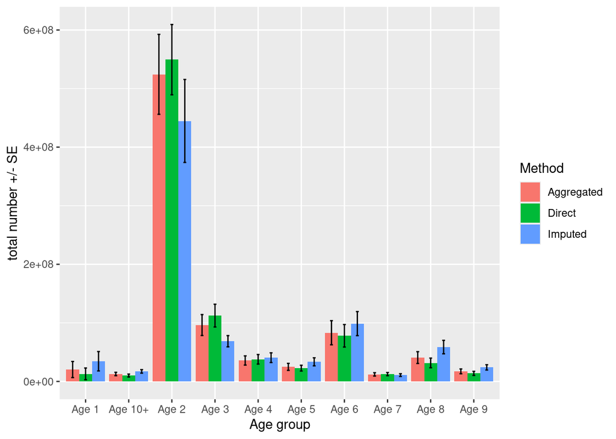

```r
totalEstimates <- readRDS("../data/estimates_caa.rds")
totalEstimates$ESTIMATES$Method="Direct"
imputedTotalEstimates$ESTIMATES$Method="Imputed"
totalAggregatedEstimates$ESTIMATES$Method="Aggregated"

comparison <- rbind(totalEstimates$ESTIMATES[totalEstimates$ESTIMATES$variable=="Abundance"], imputedTotalEstimates$ESTIMATES[imputedTotalEstimates$ESTIMATES$variable=="Abundance"], totalAggregatedEstimates$ESTIMATES[totalAggregatedEstimates$ESTIMATES$variable=="Abundance"])

ggplot2::ggplot(comparison) +
    ggplot2::geom_col(ggplot2::aes(x=fishDomain, y=total, fill=Method), position="dodge") +
    ggplot2::geom_errorbar(ggplot2::aes(x=fishDomain, ymin=total - sqrt(varianceTotal), ymax=total + sqrt(varianceTotal), group=Method), width=.2, position=ggplot2::position_dodge(.9)) +
  ggplot2::ylab("total number +/- SE") +
  ggplot2::xlab("Age group")
```

## Test IC converted estimates

Load and aggregate example data converted from InterCatch

```r
ICconverted <- readRDS("../data/ICconvertedEstimates.rds")
desiredDomains <- ICconverted$CATCH[,.SD,.SDcol=c(ACTIVITY_DOMAIN_VARIABLES[ACTIVITY_DOMAIN_VARIABLES %in% names(ICconverted$CATCH)], "activityDomain")]
desiredDomains$activityDomain[!(desiredDomains$activityDomain %in% ICconverted$ESTIMATES$activityDomain)] <- "unsampled"
desiredDomains$activityDomain[desiredDomains$activityDomain %in% ICconverted$ESTIMATES$activityDomain] <- "sampled"
ICaggregated <- aggregateActivityDomains(ICconverted, desiredDomains)
ICaggregated$ESTIMATES
```

```
## Key: <variable, fishDomain, activityDomain, vesselFlagCountry, year, catchCategory, speciesCode>
##        variable                      fishDomain activityDomain vesselFlagCountry   year catchCategory speciesCode        total
##          <char>                          <char>         <char>            <char> <char>        <char>       <num>        <num>
##  1:   Abundance NO/2019/126441/Lan/U/Age/ 1/  1        sampled                NO   2019           Lan      126441 4.144980e+02
##  2:   Abundance NO/2019/126441/Lan/U/Age/ 1/  1      unsampled                NO   2019           Lan      126441           NA
##  3:   Abundance NO/2019/126441/Lan/U/Age/ 2/  2        sampled                NO   2019           Lan      126441 2.006890e+03
##  4:   Abundance NO/2019/126441/Lan/U/Age/ 2/  2      unsampled                NO   2019           Lan      126441           NA
##  5:   Abundance NO/2019/126441/Lan/U/Age/ 3/  3        sampled                NO   2019           Lan      126441 5.095090e+04
##  6:   Abundance NO/2019/126441/Lan/U/Age/ 3/  3      unsampled                NO   2019           Lan      126441           NA
##  7:   Abundance NO/2019/126441/Lan/U/Age/ 4/  4        sampled                NO   2019           Lan      126441 2.657690e+05
##  8:   Abundance NO/2019/126441/Lan/U/Age/ 4/  4      unsampled                NO   2019           Lan      126441           NA
##  9:   Abundance NO/2019/126441/Lan/U/Age/ 5/  5        sampled                NO   2019           Lan      126441 4.932390e+05
## 10:   Abundance NO/2019/126441/Lan/U/Age/ 5/  5      unsampled                NO   2019           Lan      126441           NA
## 11:   Abundance NO/2019/126441/Lan/U/Age/ 6/  6        sampled                NO   2019           Lan      126441 4.514030e+05
## 12:   Abundance NO/2019/126441/Lan/U/Age/ 6/  6      unsampled                NO   2019           Lan      126441           NA
```

[output cut: 112 more lines]

Check that aggregated sums to same number as disaggregated

```r
nrow(ICconverted$ESTIMATES)
```

```
## [1] 60
```

```r
nrow(ICaggregated$ESTIMATES)
```

```
## [1] 60
```

```r
sum(ICconverted$ESTIMATES$total[ICconverted$ESTIMATES$variable=="Abundance"], na.rm=T) - sum(ICaggregated$ESTIMATES$total[ICaggregated$ESTIMATES$variable=="Abundance"], na.rm=T)
```

```
## [1] 0
```

```r
sum(ICconverted$ESTIMATES$total[ICconverted$ESTIMATES$variable=="Abundance"], na.rm=T) - sum(ICaggregated$ESTIMATES$total[ICaggregated$ESTIMATES$variable=="Abundance"], na.rm=T)
```

```
## [1] 0
```

```r
sopTest(ICaggregated)
```

[output not shown]

```r
sopTest(ICconverted)
```

```
## Key: <activityDomain>
##                                               activityDomain totalWeight  sopWeight     relDiff
##                                                       <char>       <num>      <num>       <num>
##  1:       NO/2019/126441/Lan/4/NA/MIS_MIS_0_0_0_HC/27.3.a.20         120         NA          NA
##  2:          NO/2019/126441/Lan/4/NA/MIS_MIS_0_0_0_HC/27.4.a       31000         NA          NA
##  3:  NO/2019/126441/Lan/4/NA/OTB_CRU_16-31_0_0_all/27.3.a.20        5700         NA          NA
##  4:     NO/2019/126441/Lan/4/NA/OTB_CRU_16-31_0_0_all/27.4.a       96000         NA          NA
##  5:  NO/2019/126441/Lan/4/NA/OTB_CRU_32-69_0_0_all/27.3.a.20       20000         NA          NA
##  6:     NO/2019/126441/Lan/4/NA/OTB_CRU_32-69_0_0_all/27.4.a       49000         NA          NA
##  7: NO/2019/126441/Lan/4/NA/OTB_CRU_90-119_0_0_all/27.3.a.20         520         NA          NA
##  8:  NO/2019/126441/Lan/4/NA/OTB_DEF_>=120_0_0_all/27.3.a.20       37000   37496.89 0.013429586
##  9:     NO/2019/126441/Lan/4/NA/OTB_DEF_>=120_0_0_all/27.4.a     3532000 3548874.46 0.004777593
## 10:     NO/2019/126441/Lan/4/NA/OTB_DEF_>=120_0_0_all/27.4.b       21000         NA          NA
## 11:  NO/2019/126441/Lan/4/NA/SSC_DEF_>=120_0_0_all/27.3.a.20          57         NA          NA
## 12:     NO/2019/126441/Lan/4/NA/SSC_DEF_>=120_0_0_all/27.4.a      105000         NA          NA
```